# projet_STA

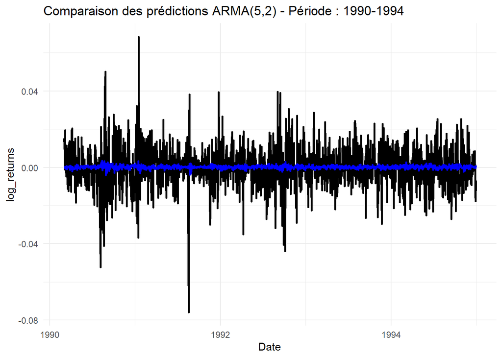

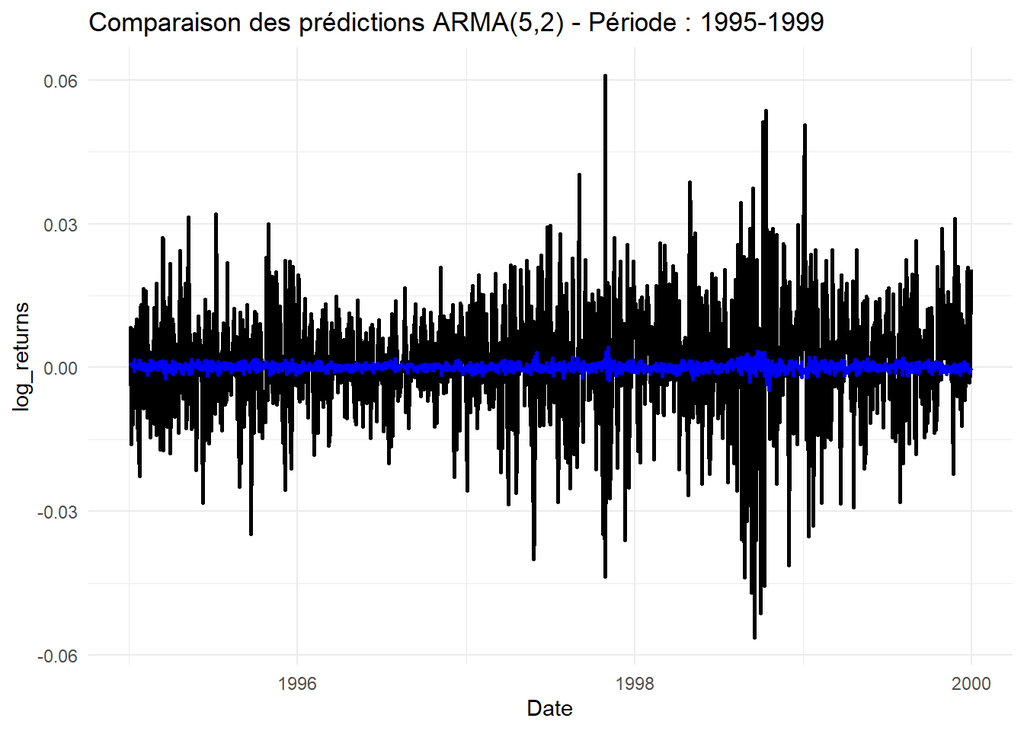

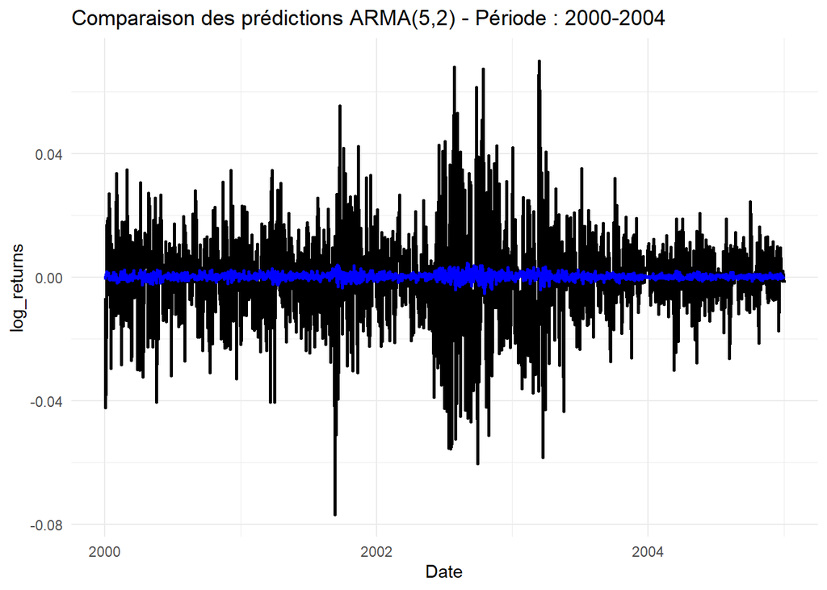

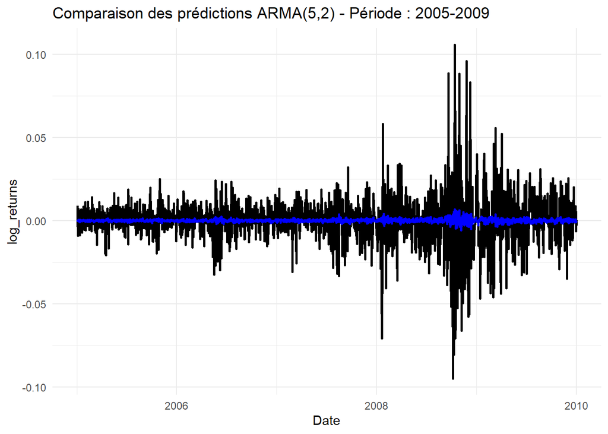

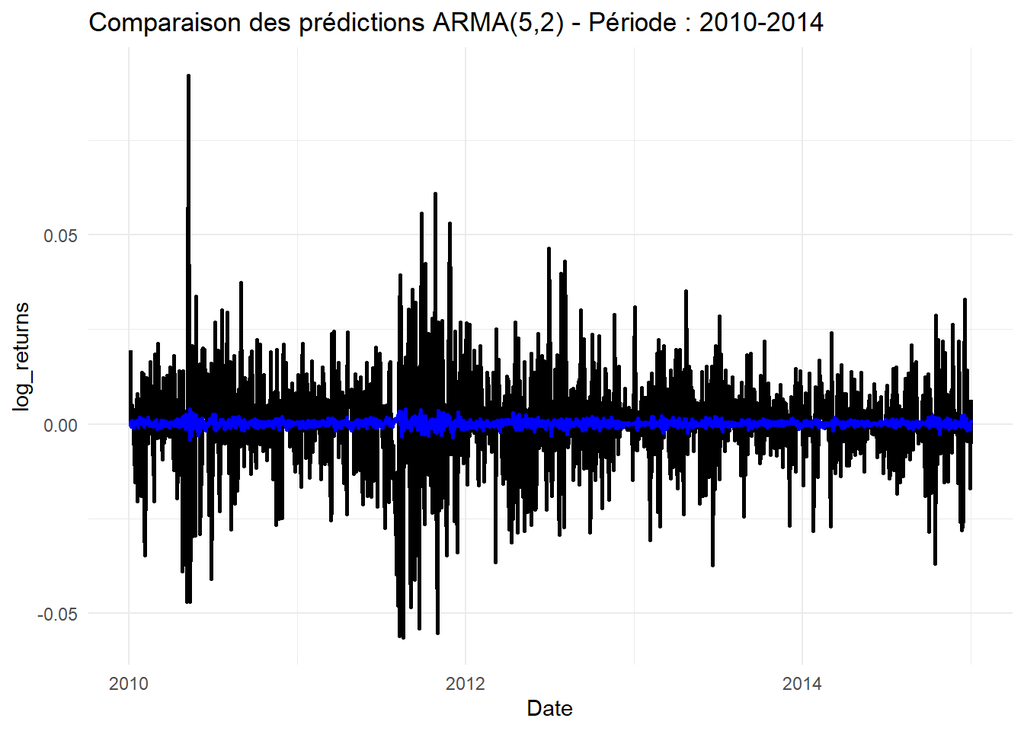

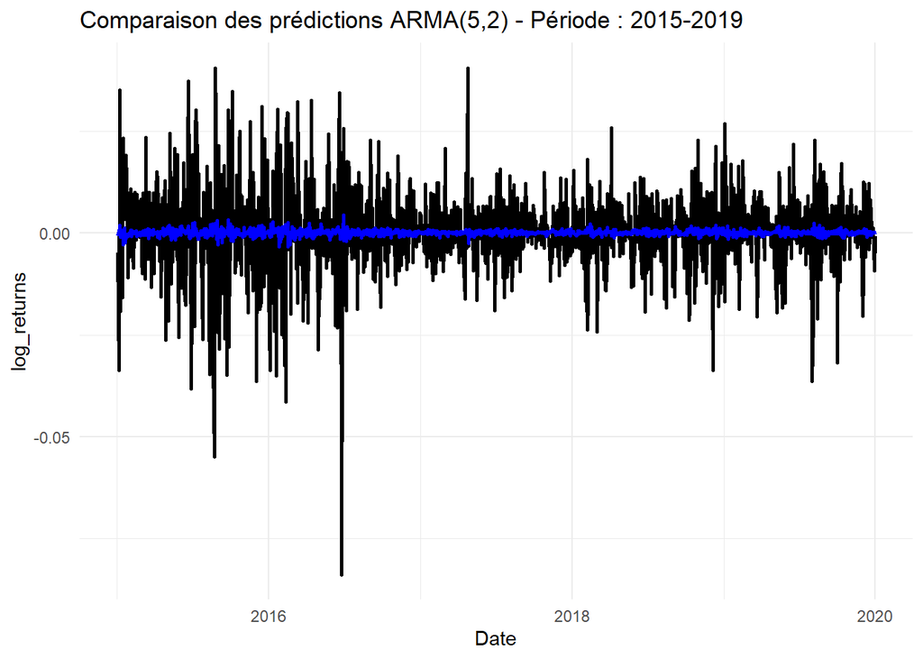

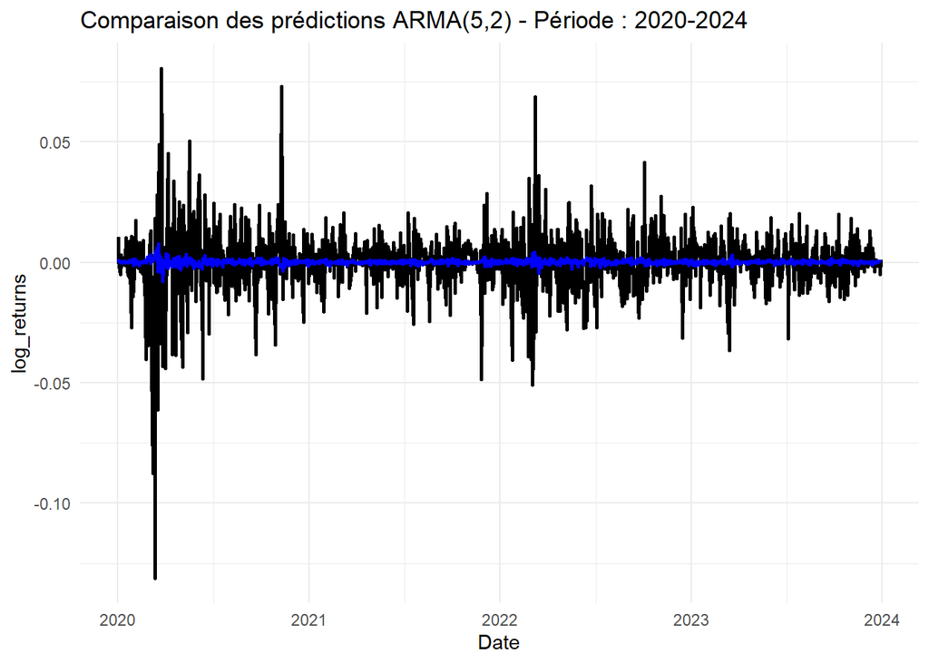

```r
library(ggplot2)
library(dplyr)

# Ajuster un modèle ARMA(5,2) sur la série log_returns
arma_model <- Arima(log_returns$Close, order = c(5, 0, 2))  # Modèle ARMA(5,2)

# Faire des prédictions in-sample (prédictions sur les points déjà observés)
predictions <- fitted(arma_model)

# Préparer les données pour ggplot (conversion de l'objet xts en dataframe)
plot_data <- data.frame(
  Time = index(log_returns),                # Extraire les dates depuis l'objet xts
  Observed = as.vector(coredata(log_returns$Close)),  # Convertir en vecteur
  Predicted = predictions                   # Ajouter les prédictions
)

# Ajouter une colonne pour les tranches de 5 ans
plot_data <- plot_data %>%
  mutate(Year = as.numeric(format(Time, "%Y")),  # Extraire l'année
         Period = paste0(floor(Year / 5) * 5, "-", floor(Year / 5) * 5 + 4))  # Grouper par tranche de 5 ans

# Découper les données en tranches de 5 ans
periods <- unique(plot_data$Period)  # Identifier toutes les tranches de 5 ans

# Boucle pour générer un graphique par tranche de 5 ans
for (period in periods) {
  # Filtrer les données pour la tranche actuelle
  period_data <- filter(plot_data, Period == period)

  # Générer un graphique pour la tranche actuelle
  p <- ggplot(period_data, aes(x = Time)) +
    geom_line(aes(y = Observed), color = 'black', linewidth = 1) +  # Série observée en noir
    geom_line(aes(y = Predicted), color = 'blue', linewidth = 1) +  # Prédictions en bleu
    labs(title = paste("Comparaison des prédictions ARMA(5,2) - Période :", period),
         x = "Date", y = "log_returns") +
    theme_minimal()

  # Afficher le graphique
  print(p)
}
```

```r
# Calculer les erreurs
errors <- plot_data$Observed - plot_data$Predicted

# Calculer le RMSE
rmse <- sqrt(mean(errors^2))

# Calculer le MAE
mae <- mean(abs(errors))

# Afficher les résultats
cat("Performance du modèle ARMA(5,2):\n")
```

```
## Performance du modèle ARMA(5,2):
```

```r
cat("RMSE: ", rmse, "\n")
```

```
## RMSE:  0.01353883
```

```r
cat("MAE: ", mae, "\n")
```

```
## MAE:  0.009558319
```

```r
#sur un sous échantillon :

# Exemple : sélectionner les données pour janvier 2015
subsample_month <- filter(plot_data, Year == 2008 & format(Time, "%m") == "10")

# Calculer les erreurs pour ce mois
errors_month <- subsample_month$Observed - subsample_month$Predicted

# Calculer le RMSE pour ce mois
rmse_month <- sqrt(mean(errors_month^2))

# Calculer le MAE pour ce mois
mae_month <- mean(abs(errors_month))

# Afficher les résultats pour le mois spécifié
cat("Performance du modèle ARMA(5,2) pour un mois précis:\n")
```

```
## Performance du modèle ARMA(5,2) pour un mois précis:
```

```r
cat("RMSE: ", rmse_month, "\n")
```

```
## RMSE:  0.04975536
```

```r
cat("MAE: ", mae_month, "\n")
```

```
## MAE:  0.03975501
```

==> comme les prédictions sont toujours nulles et qu’on fait une moyenne sur beaucoup d’échantillons, les irrégularités sont vite effacées et on obtient un MAE très faible (attention à l’échelle, car ce sont des log returns). Par ailleurs, si on observe sur un mois précis (crise de 2008 par exemple), on observe que les métriques de performance changent grandement. Par ailleurs, les prédictions sont toujours retardées (c’est induit par le modèle que l’on choisit), et d’intensité faible.

```r
# Définir les paramètres pour les modèles ARMA
p_values <- 4:7  # Valeurs de p
q_values <- 4:7  # Valeurs de q

# Stocker les modèles et leurs résultats
models <- list()
valid_models <- list()
aic_values <- c()
bic_values <- c()
box_test_results <- list()

# Ajustement des modèles ARMA et vérification de la blancheur des résidus
for (p in p_values) {
  for (q in q_values) {
    model_name <- paste0("ARIMA", p, q)

    # Ajuster le modèle ARUMA(p,1, q)
    models[[model_name]] <- arima(cac40_close, order = c(p, 1, q))

    # Récupérer les résidus et effectuer le test de Ljung-Box
    resid <- residuals(models[[model_name]])
    box_test <- Box.test(resid, lag = 30, type = "Ljung-Box")

    # Stocker le résultat du test
    box_test_results[[model_name]] <- box_test

    # Si les résidus sont blancs (p-value > 0.05), ajouter à la liste des modèles valides
    if (box_test$p.value > 0.05) {
      valid_models[[model_name]] <- models[[model_name]]
      aic_values[model_name] <- AIC(models[[model_name]])
      bic_values[model_name] <- BIC(models[[model_name]])
    }
  }
}

# Afficher les résultats des tests de blancheur
cat("Résultats des tests de blancheur des résidus (p-value) :\n")
```

```
## Résultats des tests de blancheur des résidus (p-value) :
```

```r
for (model_name in names(box_test_results)) {
  cat(model_name, ": p-value =", box_test_results[[model_name]]$p.value, "\n")
}
```

```
## ARIMA44 : p-value = 0.0246042
## ARIMA45 : p-value = 0.05457354
## ARIMA46 : p-value = 0.03070217
## ARIMA47 : p-value = 0.03365362
## ARIMA54 : p-value = 0.04997983
## ARIMA55 : p-value = 0.04733261
## ARIMA56 : p-value = 0.02920327
## ARIMA57 : p-value = 0.03414758
## ARIMA64 : p-value = 0.03129342
## ARIMA65 : p-value = 0.02983211
## ARIMA66 : p-value = 0.0301339
## ARIMA67 : p-value = 0.02987029
## ARIMA74 : p-value = 0.05750915
## ARIMA75 : p-value = 0.03417813
## ARIMA76 : p-value = 0.02992116
## ARIMA77 : p-value = 0.1589983
```

```r
# Évaluer les modèles valides uniquement
if (length(valid_models) > 0) {
  cat("\nCritères AIC et BIC pour les modèles valides :\n")
  aic_results <- data.frame(Model = names(aic_values), AIC = aic_values, BIC = bic_values)
  print(aic_results[order(aic_results$AIC), ])  # Trier par AIC

  # Identifier le meilleur modèle parmi les modèles valides
  best_model <- names(which.min(aic_values))
  cat("\nMeilleur modèle basé sur AIC parmi les modèles valides :", best_model, "\n")
} else {
  cat("\nAucun modèle n'a passé le test de blancheur des résidus.\n")
}
```

```
##
## Critères AIC et BIC pour les modèles valides :
##           Model      AIC      BIC
## ARIMA45 ARIMA45 93252.35 93322.93
## ARIMA77 ARIMA77 93253.24 93359.11
## ARIMA74 ARIMA74 93255.88 93340.58
##
## Meilleur modèle basé sur AIC parmi les modèles valides : ARIMA45
```